# MAGOLEGO SNA 2019 Egor Krotov HW #2

### 2. Compute centrality metrics

Compute for your network:

- Degree centrality
- Closeness centrality
- Betweenness centrality
- Eigenvector centrality
- Bonacich power centrality
- Alpha centrality

```r
friends_graph_degree_cent = friends_graph_degree
friends_graph_close = closeness(friends_graph)
friends_graph_between = betweenness(friends_graph)
friends_graph_eigen = eigen_centrality(friends_graph)
friends_graph_bona = bonpow(friends_graph)
friends_graph_alpha = alpha.centrality(friends_graph)
```

Output six plots corresponding to six centrality metrics you’ve computed:

- Use first names of your friends as node labels on the graph (you may hide this information if you wish – change it by integer ID).
- Keep the same layout of the network.
- Make node sizes and colours proportional to the respective centrality metrics.

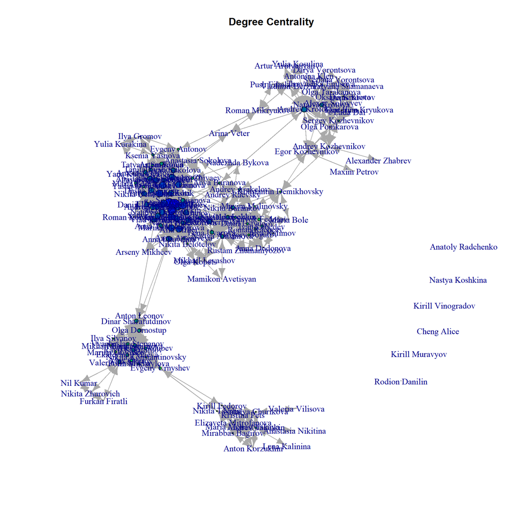

```r
palette = colorRampPalette(c("green", "blue"))
friends_graph_layout = layout.fruchterman.reingold(friends_graph)
friends_graph_v_color = palette(100)[as.numeric(cut(friends_graph_degree_cent, breaks = 100))]

graph_scale = function(l) scale(l, center = min(l), scale = max(l) - min(l))
friends_graph_v_size = function(l) 0 + 5 * graph_scale(l)

plot(friends_graph, layout = friends_graph_layout, main = "Degree Centrality", vertex.color = friends_graph_v_color, vertex.size = friends_graph_v_size(friends_graph_degree_cent))
```

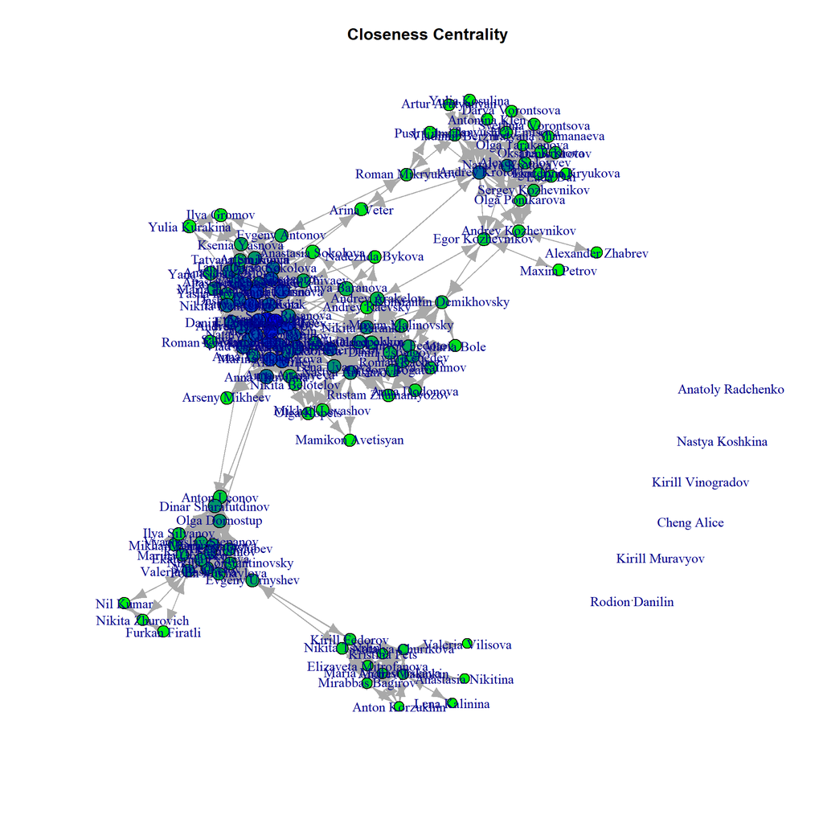

```r
plot(friends_graph, layout = friends_graph_layout, main = "Closeness Centrality", vertex.color = friends_graph_v_color, vertex.size = friends_graph_v_size(friends_graph_close))
```

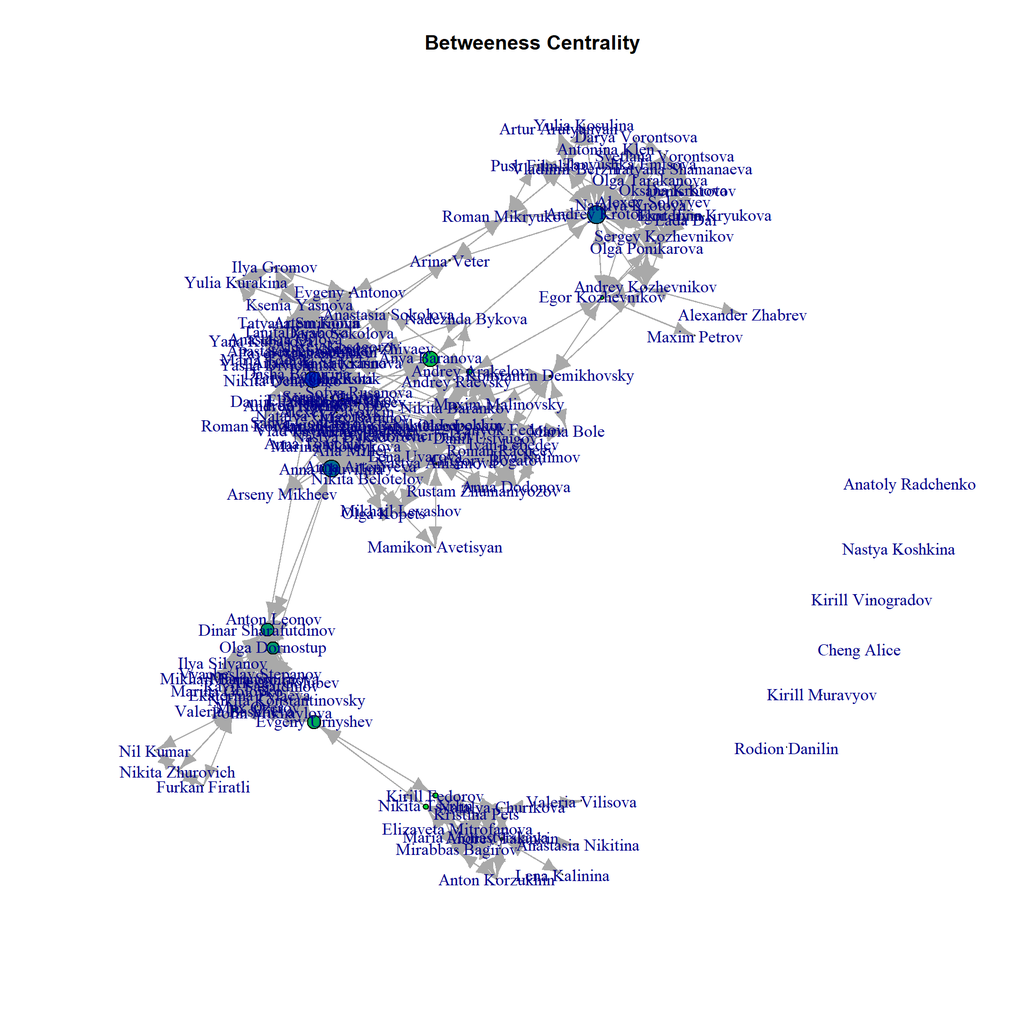

```r
plot(friends_graph, layout = friends_graph_layout, main = "Betweeness Centrality",vertex.color = friends_graph_v_color, vertex.size = friends_graph_v_size(friends_graph_between))
```

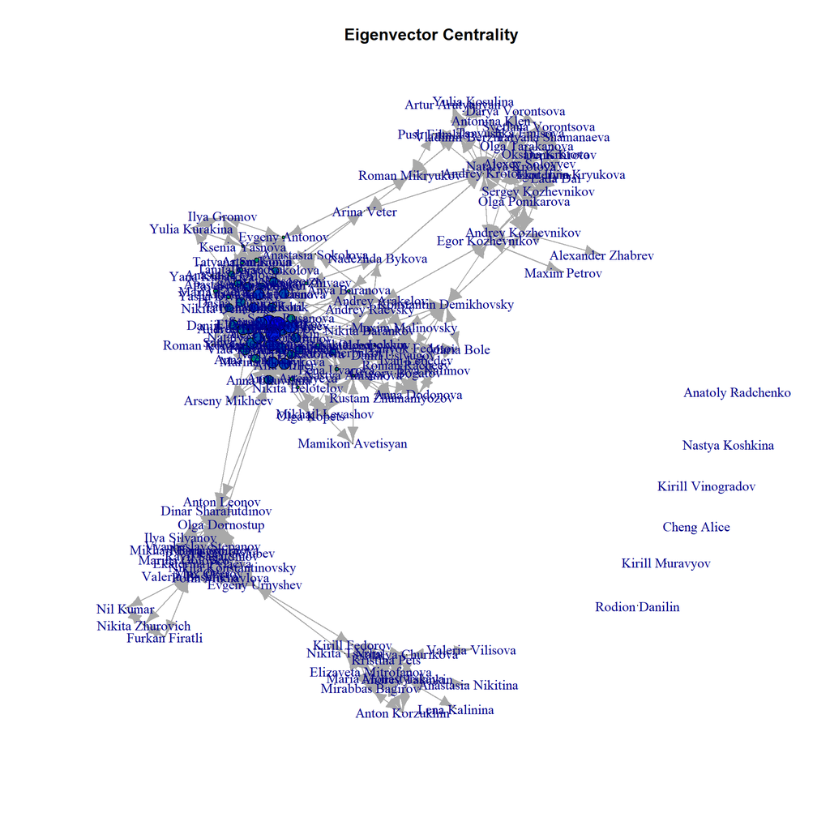

```r
plot(friends_graph, layout = friends_graph_layout, main = "Eigenvector Centrality",vertex.color = friends_graph_v_color, vertex.size = friends_graph_v_size(friends_graph_eigen$vector))
```

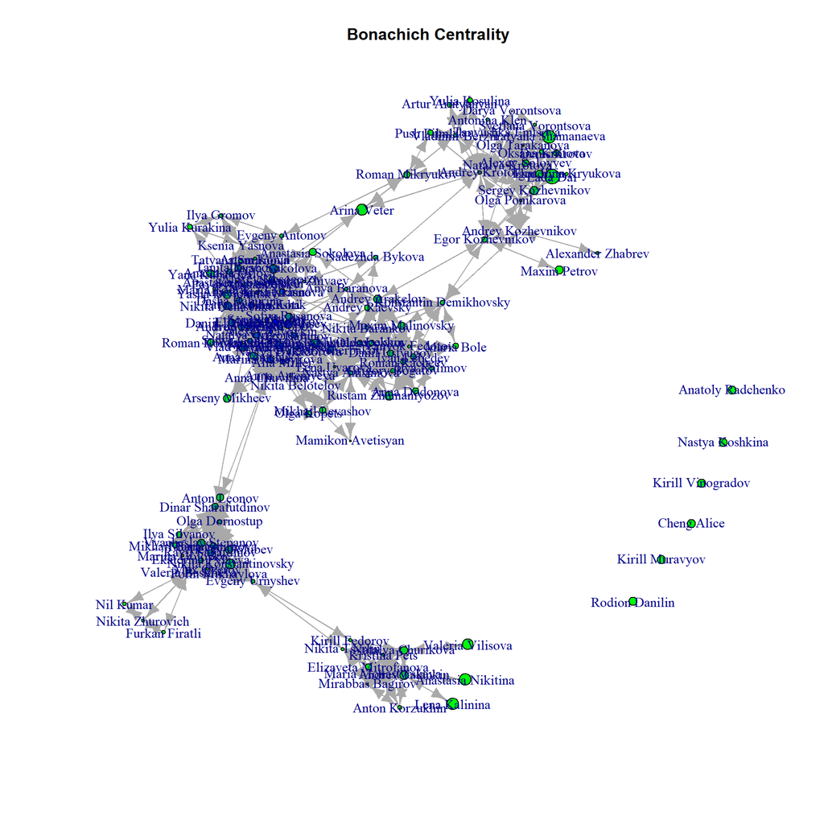

```r
plot(friends_graph, layout = friends_graph_layout,main = "Bonachich Centrality", vertex.color = friends_graph_v_color, vertex.size = friends_graph_v_size(friends_graph_bona))
```